# Bootcamp Data Manipulation Exercises

Regina Zweng

9/28/2017

1. Researchers will often summarize P-values in genome-wide studies by making a QQ-plot. The QQ-plot has the observed (the ones you actually computed) P-values on the y-axis vs. the expected P-values on the x-axis. For a properly calibrated test, under the null hypothesis (i.e. meaning all the SNPs are in Hardy-Weinberg equilibrium) the observed P-values will follow a uniform distribution. This means that 1% of P-values will be <0.01, 5% of P-values will be <0.05, 25% of P-values will be <0.25, etc. A QQ plot is a nice way to visualize whether the P-values indeed follow a uniform distribution.
1. To start let’s revisit our tests of Hardy-Weinberg. Go back and perform the chi-square test for Hardy -Weinberg that we did in class on all SNPs in the “hapmap_CEU_r23a_chr2_ld.txt” file. Hint: you already have the code for this… Save your P-values in a vector called “pvals”.

```r
setwd("/Users/reginazweng/Documents/GitHub/Rbootcamp2")

# Load a data set
snpsDataFrame=read.table('hapmap.txt',header=TRUE)

# Because the data are really just a large numeric matrix, we convert the dataframe to a matrix:
snps=as.matrix(snpsDataFrame)

compute_chisquare=function(x){
  freq=sum(x,na.rm=TRUE)/(2.0*sum(!is.na(x)))
    cnt0=sum(x==0,na.rm=TRUE)
    cnt1=sum(x==1,na.rm=TRUE)
    cnt2=sum(x==2,na.rm=TRUE)
    obscnts=c(cnt0,cnt1,cnt2)
    #print(obscnts)
    n=sum(obscnts)
    expcnts=c((1-freq)^2,2*freq*(1-freq),freq^2)*n
    chisq=sum((obscnts-expcnts)^2/expcnts)
    return(chisq)
}

# Apply the compute_chi_square function to each snp
chisqs=apply(snps,1,compute_chisquare)
```

2. What proportion of P-values from the test (put the vector called “pvals”) are <0.05? What proportion are <0.01? Are any <0.001?

```r
# Compute p-values for each chi-square value using the pchisq function
pvals=pchisq(chisqs,1,lower.tail=FALSE)

# Count the number of pvals smaller than the significance threshold of 0.05 and divide by total number of p-values
signifthres<-0.05
sum(pvals<signifthres)/length(chisqs)
```

```
## [1] 0.04509218
```

```r
# Count the number of pvals smaller than the significance threshold of 0.01
signifthres<-0.01
sum(pvals<signifthres)/length(chisqs)
```

```
## [1] 0.01021425
```

```r
# Count the number of pvals smaller than the significance threshold of 0.001
signifthres<-0.001
sum(pvals<signifthres)/length(chisqs)
```

```
## [1] 0.00124564
```

The proportion of P-values that are <0.05 is 0.04509218. The proportion of P-values that are <0.01 is 0.01021425. The proportion of P-values that are <0.001 is 0.00124564.

3. How many SNPs were tested for departures from Hardy-Weinberg equilibrium? Hint: How many P-values do you have? Second hint: Try using the “length” function. Save this value in the variable called “num_pval”.

```r
num_pval<-length(chisqs)
num_pval
```

```
## [1] 4014
```

There were 4014 SNP’s tested for departures from Hardy-Weinberg equilibrium.

4. Say that you have “num_pval” total P-values. Assuming that the null hypothesis is true (i.e. all SNPs are in Hardy-Weinberg), the smallest P-values is expected to be 1/num_pval. The second smallest P-value is expected to be 2/num_pval. The third smallest P-value is expected to be 3/num_pval, etc. The largest P-value is expected to be num_pval/num_pval (or 1). Calculate the vector of expected P-values for the chi-square test. Save these in the vector called “exp_pvals”.

```r
vect<-seq(1,4014,by=1)
exp_pvals<-vect/4014
```

5. The observed P-values in the “pvals” vector are in the order that they SNPs appear across the chromosome. We need to sort them, smallest to largest. Use the “sort” function to sort the P-values. Store them in the vector “sort_pvals”.

```r
sort_pvals<-sort(pvals)
```

6. In order to see what is happening with the small P-values (these are the ones we really care about), people often take the –log10(Pvalue). Find the –log10 of the observed and expected P-values. Store these in the vector “log_sort_pvals” and “log_exp_pvals”.

```r
log_sort_pvals<-(-log(sort_pvals))
log_exp_pvals<-(-log(exp_pvals))
```

7. You’re ready to make the QQ plot! Plot the “log_sort_pvals” vs. the “log_exp_pvals”.
8. Where should these P-values fall under the null hypothesis? They should fall along the diagonal. Add a diagonal line to the QQ plot.
9. When you’re done, your plot should look something like this:

[figure not shown]

```r
plot(log_exp_pvals,log_sort_pvals,xlab="−log10(expected P−value)",ylab="−log10(observed P−value)")
abline(0,1,col="2",lty=2,lwd=2)
```

2. Researchers are very interested in testing whether certain alleles are present in higher frequency in individuals with traits, such as type 2 diabetes. We have blood glucose levels for the 60 individuals in this study.
1. Load the file “pheno.sim.2014.txt”. Store the phenotypes in a data frame called “zz”. The second column in this file contains the blood glucose measurements. Hint: you probably want to use “header=T” in the “read.table” command.

```r
setwd("/Users/reginazweng/Documents/GitHub/Rbootcamp2")

# Load a data set
zz=snpsDataFrame=read.table('phenotype.txt',header=TRUE)
```

2. Find the value of the phenotype such that 25% of the individuals have a phenotype LESS than this value.

```r
pheno=zz$glucose_mmolperL
summary(pheno)
```

```
##    Min. 1st Qu.  Median    Mean 3rd Qu.    Max.
##   3.595   4.769   5.328   5.888   7.355  10.360
```

```r
#the answer is the 1st quantile (4.768756)
```

3. Find the value of the phenotype such that 25% of the individuals have a phenotype GREATER than this value (i.e. 75% of the individuals have a phenotype LESS than this value).

```r
summary(pheno)
```

```
##    Min. 1st Qu.  Median    Mean 3rd Qu.    Max.
##   3.595   4.769   5.328   5.888   7.355  10.360
```

```r
#The answer is the 3rd quartile (7.354975)
```

4. Make a density plot of the distribution of phenotypes (i.e. the blood glucose levels). Add vertical lines to the plot to denote the 25% and 75% tails of the distribution.

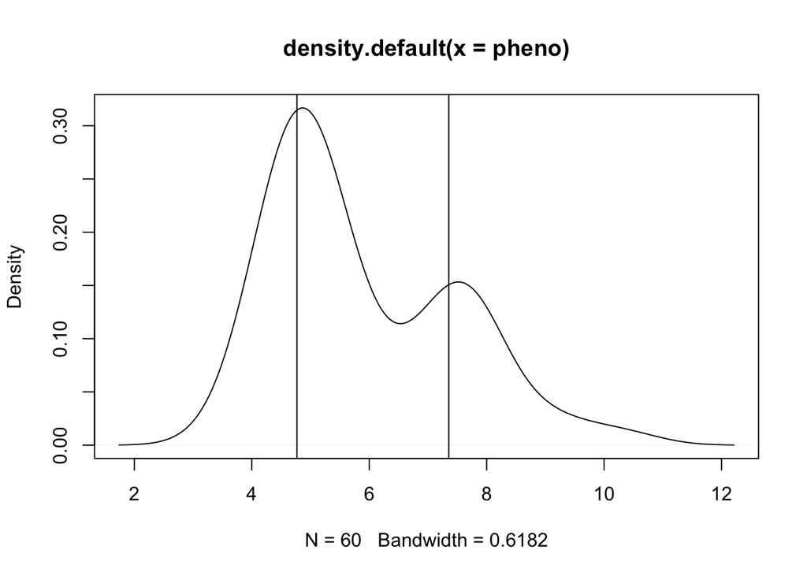

```r
plot(density(pheno))
abline(v=4.769)
abline(v=7.355)
```